# Earthquake families in catalog v6.0 (nearest-neighbour clustering)

Branch `analysis/v60-clusters` (commit dc8b3640), 2026-11-26. Private working product; not peer reviewed. Same method, parameters and code as the v5.1 clustering (PR #42; `v51_clusters_zbz.py`, now with `--catalog v6.0`), run on catalog v6.0 with its converged Route A magnitudes (D-B091).

## What changed against v5.1

- Inputs. Locations: catalog v6.0 (NonLinLoc in model v0.4.1 with SSST station terms and coherence relocation, D-B100) instead of v5.1. Magnitudes: the converged Route A values of D-B091 carried in the v6.0 catalog (130,348 from the v5.1 table, 764 from the v4.1 table) instead of the stored values used for v5.1. Median change of M (converged minus stored) per region box: AX -0.06, EN -0.26, BL -0.70, GO -0.29, MT -0.29, WA +0.01, OR -0.06, PU +0.02, ON +0.01 (Fig. 1).
- Events used: 168,861 located earthquakes (v5.1: 168,406); 159 rows without a hypocentre (v5.1: 623) and 3,322 flagged as not earthquakes by the v6.0 `event_flag` (v5.1: 3,313, from the v5.1 magnitude table's is_earthquake). Above Mc (the analysis set): 30,754 events (v5.1: 30,201).
- Families: 2,101 in v6.0 against 2,097 in v5.1 (975 / 214 / 912 mainshock-aftershock / swarm / multiplet, against 994 / 200 / 903). Background (single events above Mc): 59.6 % against 62.3 %.
- Completeness and b, v5.1 -> v6.0 (same Mc rule: maximum curvature + 0.2, largest yearly value). Mc: AX 0.65 -> 0.75, EN 2.35 -> 2.05, BL 2.45 -> 1.75, GO 2.55 -> 2.25, MT 1.95 -> 1.65, WA 1.45 -> 1.65, OR 1.85 -> 1.75, PU 1.25 -> 1.25, ON 1.65 -> 1.65. b: AX 0.72 -> 0.71, EN 0.84 -> 0.86, BL 1.27 -> 1.18, GO 1.14 -> 1.18, MT 1.06 -> 1.05, WA 1.08 -> 1.13, OR 0.88 -> 1.11, PU 1.27 -> 1.27, ON 0.81 -> 0.94. Events above Mc: AX 4,410 -> 3,320, EN 554 -> 680, BL 7,230 -> 9,431, GO 1,199 -> 1,005, MT 7,412 -> 7,620, WA 706 -> 428, OR 398 -> 399, PU 3,906 -> 4,058, ON 4,386 -> 3,813.
- Of the 2,097 v5.1 families, 1,550 are kept in v6.0, 119 grown, 13 split, 59 merged into a larger family, 2 changed and 354 dissolved (less than half of their events in any v6.0 family). Of the 174 v5.1 families with 20 or more events, 144 are kept, 9 grown, 4 split, 12 merged, 0 changed and 5 dissolved. 429 v6.0 families have no v5.1 counterpart.
- Cause of the 547 v5.1 families that are not kept: the same status already with the converged magnitudes on the v5.1 locations and not with the v6.0 locations alone: 204 (magnitude change); the reverse: 197 (location change); either change alone gives it: 83; only both together: 63. Families dissolved by the magnitude change: 259 (v5.1 locations) and 270 (v6.0 locations); by the location change: 176 (stored M) and 193 (converged M). Split or merged: magnitude change 35 and 34, location change 85 and 75 (matching table below).
- Large families that changed: v6.0 family F1140 (BL, 2014-03-11, mainshock-aftershock, 1,049 events, grown against v5.1) holds the v5.1 families F1170 (swarm, 480 events, grown); F1165 (swarm, 104 events, grown); F1167 (swarm, 34 events, grown); F1166 (mainshock-aftershock, 33 events, grown); F1178 (swarm, 33 events, grown). v6.0 family F625 (BL, 2013-01-30, mainshock-aftershock, 422 events, grown against v5.1) holds the v5.1 families F597 (mainshock-aftershock, 128 events, grown). v6.0 family F1939 (BL, 2015-06-27, swarm, 218 events, merged against v5.1) holds the v5.1 families F1948 (swarm, 50 events, merged); F1947 (mainshock-aftershock, 48 events, merged); F1949 (swarm, 36 events, merged).
- Unchanged: method, parameters (df 1.6, distance floor 0.5 km, link cap max(10 km, 3 L(M))), the nine region boxes, the classification rules, the 2-D epicentral distance of the main run.

## Caveats

- Axial depths in v6.0 are about 0.22 km deeper than in v5.1 (median, SSST passes; D-B100, to be fixed in v6.1). The main run uses epicentral (2-D) distance, so families, parents and thresholds do not use depth. Depth enters the 3-D variants d3 and d3q, the family depth columns (depth_good_*) and the swarm-versus-mainshock depth test; read Axial depths there with this offset in mind.
- The magnitudes were computed with the v5.1 hypocentres (or the v4 hypocentres for the 764 events not in the v5.1 table) and are not recomputed with the v6.0 hypocentres (catalog README).
- Fault surfaces v1 were fitted on v5.1 locations. The join is by event ID with the faults piece's assignment (on_surface_strict), as for v5.1; it is not redone with the v6.0 locations (numbers in the fault section).
- Variant mc_best uses Mc_best of the converged regional Mc map table (`/wd1/mdenolle_data/magnitude_converged/mc_maps_v41/mc_regional.csv`, rows variant all, period all; converged v4.1 magnitudes on v4 locations); there is no Mc map on v6.0 locations. The main run computes its Mc from the v6.0 magnitudes with the v4 rule.
- Mc is the largest yearly maximum-curvature value. In the year that sets Mc, the two largest 0.1-unit bins differ by 2-19 % (`mc_edge_check.csv`; WA: 2010, 40 vs 37 events), so a small change of the magnitudes can move Mc by a bin or two. WA shows the effect: its magnitudes changed by +0.01 (median) and its Mc by +0.20 (1.45 -> 1.65), which changes its analysis set from 706 to 428 events.
- No coherence relocation in the Mendocino region in v6.0 (D-B098): MT epicentres are the SSST locations. The waveform-review sets P1 and P2 are matched by event ID from the v5.1 review.
- Migration and the sqrt(t) fits use tier A-C epicentres; the family classification does not use them. Treat fault and swarm-migration results as provisional until a cross-correlation double-difference catalog exists.

## Headline numbers (v6.0)

2,101 families: 975 mainshock-aftershock (147 with 5 or more events above Mc), 214 swarm, 912 multiplet. 30,754 events above Mc, 59.6 % of them background. With the events below Mc attached: 29,527 events in families, 4,898 linked to a single event above Mc.

| region | name | events ≥ Mc | Mc | b | df | log eta0 | log eta0 (5% shuffled) | D | % bg | % MA | % swarm | % mult | families | MA | MA n≥5 | swarms | multiplets |
| --- | --- | --- | --- | --- | --- | --- | --- | --- | --- | --- | --- | --- | --- | --- | --- | --- | --- |
| AX | Axial Seamount | 3320 | 0.75 | 0.71 | 1.60 | -6.11 | -6.98 | 2.46 | 61.30 | 11.00 | 22.00 | 5.80 | 249 | 130 | 9 | 33 | 86 |
| EN | Endeavour-Explorer | 680 | 2.05 | 0.86 | 1.60 | -4.40 | -5.73 | 3.38 | 49.30 | 42.80 | 5.30 | 2.60 | 35 | 23 | 6 | 4 | 8 |
| BL | Blanco transform | 9431 | 1.75 | 1.18 | 1.60 | -5.77 | -6.81 | 2.95 | 49.40 | 17.60 | 23.10 | 9.90 | 766 | 286 | 49 | 96 | 384 |
| GO | Gorda ridge and plate | 1005 | 2.25 | 1.18 | 1.60 | -5.59 | -6.39 | 2.85 | 63.30 | 17.00 | 10.90 | 8.80 | 85 | 39 | 10 | 11 | 35 |
| MT | Mendocino triple junction | 7620 | 1.65 | 1.05 | 1.60 | -5.26 | -6.42 | 2.37 | 57.00 | 38.00 | 1.30 | 3.70 | 376 | 235 | 37 | 14 | 127 |
| WA | Offshore Washington | 428 | 1.65 | 1.13 | 1.60 | -3.57 | -3.84 | 1.85 | 82.50 | 7.70 | 3.50 | 6.30 | 29 | 14 | 0 | 2 | 13 |
| OR | Offshore Oregon | 399 | 1.75 | 1.11 | 1.60 | -3.01 | -4.91 | 1.73 | 63.20 | 20.30 | 6.00 | 10.50 | 31 | 10 | 2 | 3 | 18 |
| PU | Puget Lowland | 4058 | 1.25 | 1.27 | 1.60 | -4.26 | -4.60 | 1.86 | 77.70 | 11.60 | 5.10 | 5.50 | 236 | 125 | 21 | 14 | 97 |
| ON | Onshore and other | 3813 | 1.65 | 0.94 | 1.60 | -3.89 | -4.41 | 2.25 | 67.00 | 15.10 | 9.30 | 8.60 | 294 | 113 | 13 | 37 | 144 |

Mc: v4 rule on the v6.0 magnitudes (maximum curvature of the 0.1 bins + 0.2, largest yearly value over years with 200 or more events); b: Aki maximum likelihood above Mc; df 1.6 in all regions; eta0: crossing of the two weighted components of a Gaussian mixture on log10 eta. D: Ashman separation of the mixture.

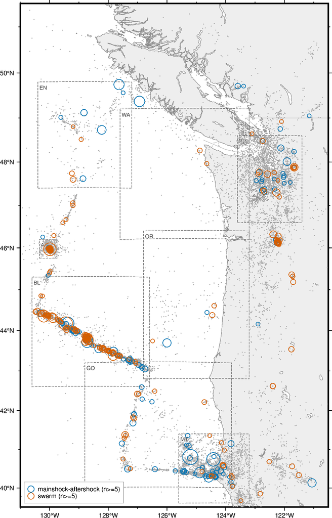

Families with 5 or more events above Mc at their largest event (blue mainshock-aftershock, orange swarm; symbol size grows with n); grey dots: background events above Mc; dashed boxes: the nine regions.

### Completeness and b

| region | n | with M | Mc_all | Mc b-stability | Mc | n_above | b | b_err | df_est | Mc_best (mc_maps_v41) | b_at_Mc_best |
| --- | --- | --- | --- | --- | --- | --- | --- | --- | --- | --- | --- |
| AX | 26788 | 13963 | 0.55 | 0.20 | 0.75 | 3310 | 0.71 | 0.01 | 0.38 | 0.30 | 0.77 |
| EN | 2467 | 1865 | 1.95 | 1.70 | 2.05 | 677 | 0.86 | 0.04 | 1.15 | 1.60 | 0.77 |
| BL | 42795 | 31693 | 1.75 | 1.80 | 1.75 | 9409 | 1.18 | 0.01 | 0.98 | 1.60 | 1.14 |
| GO | 10285 | 7157 | 2.05 | 3.30 | 2.25 | 1004 | 1.18 | 0.05 | 1.11 | 1.90 | 1.25 |
| MT | 38110 | 28685 | 1.35 | 1.50 | 1.65 | 7603 | 1.05 | 0.01 | 1.32 | 1.50 | 1.02 |
| WA | 3474 | 2798 | 1.35 | 1.30 | 1.65 | 428 | 1.13 | 0.06 | 1.21 | 1.30 | 1.08 |
| OR | 1737 | 1260 | 1.65 | 1.60 | 1.75 | 399 | 1.11 | 0.06 | 0.81 | 1.50 | 1.07 |
| PU | 13730 | 13048 | 1.15 | 1.20 | 1.25 | 4045 | 1.27 | 0.02 | 1.46 | 1.30 | 1.29 |
| ON | 29475 | 27235 | 1.55 | 1.40 | 1.65 | 3809 | 0.94 | 0.01 | 1.00 | 1.30 | 0.92 |

## Magnitude change against location change

Four runs with the same code: v5.1 locations or v6.0 locations, each with the stored (pre-D-B091) or the converged magnitudes. A is the committed v5.1 run, D the v6.0 run. B was run here (`--catalog v5.1 --mag converged`, folder `ref_v51_Mconv/`); C is the v6.0 variant storedM (the v5.1 stored table, else the v4.1 stored table, on the v6.0 locations). Each run sets its own Mc, b and eta0.

| run | label | events ≥ Mc | % bg | families | MA | MA n≥5 | swarms | multiplets |
| --- | --- | --- | --- | --- | --- | --- | --- | --- |
| A | v5.1 locations, stored M (v5.1 run) | 30201 | 62.3 | 2097 | 994 | 132 | 200 | 903 |
| B | v5.1 locations, converged M | 30927 | 59.7 | 2092 | 975 | 146 | 200 | 917 |
| C | v6.0 locations, stored M (variant storedM) | 30123 | 61.2 | 2127 | 1000 | 131 | 208 | 919 |
| D | v6.0 locations, converged M (v6.0 run) | 30754 | 59.6 | 2101 | 975 | 147 | 214 | 912 |

| region | Mc A | Mc B | Mc C | Mc D | b A | b B | b C | b D | log_eta0 A | log_eta0 B | log_eta0 C | log_eta0 D | pct_background A | pct_background B | pct_background C | pct_background D | n_families A | n_families B | n_families C | n_families D | n_swarm A | n_swarm B | n_swarm C | n_swarm D |
| --- | --- | --- | --- | --- | --- | --- | --- | --- | --- | --- | --- | --- | --- | --- | --- | --- | --- | --- | --- | --- | --- | --- | --- | --- |
| AX | 0.65 | 0.75 | 0.65 | 0.75 | 0.72 | 0.71 | 0.73 | 0.71 | -6.11 | -6.01 | -6.26 | -6.11 | 61.80 | 59.00 | 65.20 | 61.30 | 356.00 | 266.00 | 331.00 | 249.00 | 40.00 | 31.00 | 37.00 | 33.00 |
| EN | 2.35 | 2.05 | 2.35 | 2.05 | 0.84 | 0.86 | 0.85 | 0.86 | -4.09 | -4.09 | -4.34 | -4.40 | 49.80 | 47.70 | 50.40 | 49.30 | 32.00 | 36.00 | 34.00 | 35.00 | 5.00 | 5.00 | 4.00 | 4.00 |
| BL | 2.45 | 1.75 | 2.45 | 1.75 | 1.27 | 1.19 | 1.27 | 1.18 | -6.89 | -5.64 | -6.88 | -5.77 | 52.50 | 48.70 | 50.20 | 49.40 | 578.00 | 757.00 | 597.00 | 766.00 | 70.00 | 92.00 | 76.00 | 96.00 |
| GO | 2.55 | 2.15 | 2.65 | 2.25 | 1.14 | 1.21 | 1.15 | 1.18 | -5.47 | -5.17 | -5.74 | -5.59 | 60.30 | 60.40 | 61.10 | 63.30 | 102.00 | 107.00 | 84.00 | 85.00 | 12.00 | 14.00 | 11.00 | 11.00 |
| MT | 1.95 | 1.65 | 1.95 | 1.65 | 1.06 | 1.06 | 1.06 | 1.05 | -5.39 | -5.23 | -5.40 | -5.26 | 57.50 | 57.30 | 56.50 | 57.00 | 379.00 | 358.00 | 403.00 | 376.00 | 13.00 | 13.00 | 14.00 | 14.00 |
| WA | 1.45 | 1.65 | 1.45 | 1.65 | 1.08 | 1.12 | 1.09 | 1.13 | -3.43 | -3.53 | -3.42 | -3.57 | 84.40 | 83.40 | 83.30 | 82.50 | 42.00 | 27.00 | 42.00 | 29.00 | 3.00 | 2.00 | 2.00 | 2.00 |
| OR | 1.85 | 1.75 | 1.85 | 1.75 | 0.88 | 1.10 | 0.89 | 1.11 | -3.22 | -3.04 | -2.66 | -3.01 | 75.60 | 67.90 | 60.50 | 63.20 | 24.00 | 24.00 | 33.00 | 31.00 | 0.00 | 0.00 | 3.00 | 3.00 |
| PU | 1.25 | 1.25 | 1.25 | 1.25 | 1.27 | 1.27 | 1.27 | 1.27 | -4.21 | -4.23 | -4.25 | -4.26 | 78.80 | 78.50 | 78.00 | 77.70 | 232.00 | 240.00 | 229.00 | 236.00 | 14.00 | 14.00 | 14.00 | 14.00 |
| ON | 1.65 | 1.65 | 1.65 | 1.65 | 0.81 | 0.94 | 0.81 | 0.94 | -3.66 | -3.93 | -3.68 | -3.89 | 69.60 | 71.30 | 66.40 | 67.00 | 352.00 | 277.00 | 374.00 | 294.00 | 43.00 | 29.00 | 47.00 | 37.00 |

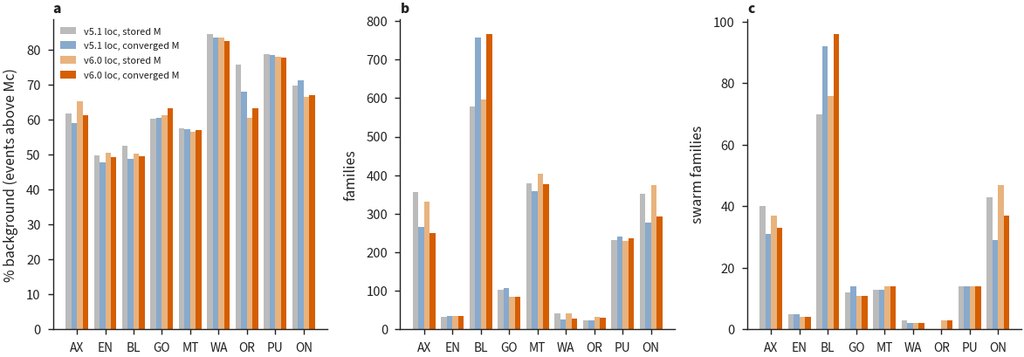

Family matching between the runs (shared event IDs, members including the attached events below Mc; a family is kept when at least half of its events are in one family of the other run and that family has at least half of its events from it; dissolved when less than half of its events are in any family of the other run). Columns old_*: status of the families of the first run; new_*: of the second run.

| pair | what | n_old | n_new | old_kept | old_grown | old_split | old_merged | old_changed | old_dissolved | new_kept | new_grown | new_split_part | new_merged | new_changed | new_new |
| --- | --- | --- | --- | --- | --- | --- | --- | --- | --- | --- | --- | --- | --- | --- | --- |
| A -> B | magnitude change at v5.1 locations | 2097 | 2092 | 1730 | 73 | 6 | 29 | 0 | 259 | 1735 | 22 | 16 | 14 | 6 | 299 |
| C -> D | magnitude change at v6.0 locations | 2127 | 2101 | 1780 | 42 | 6 | 28 | 1 | 270 | 1786 | 15 | 14 | 13 | 8 | 265 |
| A -> C | location change with stored M | 2097 | 2127 | 1744 | 91 | 16 | 69 | 1 | 176 | 1761 | 26 | 32 | 39 | 21 | 248 |
| B -> D | location change with converged M | 2092 | 2101 | 1735 | 87 | 24 | 51 | 2 | 193 | 1757 | 17 | 44 | 31 | 36 | 216 |
| A -> D | v5.1 -> v6.0 (both changes) | 2097 | 2101 | 1550 | 119 | 13 | 59 | 2 | 354 | 1567 | 31 | 25 | 33 | 16 | 429 |
| v4.1 -> D | v4.1 (converged M) -> v6.0 | 1966 | 2101 | 1444 | 74 | 28 | 54 | 5 | 361 | 1490 | 17 | 45 | 31 | 40 | 478 |

### v5.1 families not kept in v6.0, by cause

| cause | status | either alone | location | magnitude | only both together | All |
| --- | --- | --- | --- | --- | --- | --- |
|  | changed | 0 | 1 | 0 | 1 | 2 |
|  | dissolved | 51 | 99 | 173 | 31 | 354 |
|  | grown | 17 | 59 | 23 | 20 | 119 |
|  | merged | 14 | 30 | 6 | 9 | 59 |
|  | split | 1 | 8 | 2 | 2 | 13 |
|  | All | 83 | 197 | 204 | 63 | 547 |

v5.1 families with 20 or more events that are not kept (status_magnitude_only: status of the v5.1 family at v5.1 locations with the converged magnitudes; status_location_only: with the v6.0 locations and the stored magnitudes):

| v5.1 family | region | type | events | Mmax | start | status | main v6.0 family | its type | shared | status_magnitude_only | status_location_only | cause |
| --- | --- | --- | --- | --- | --- | --- | --- | --- | --- | --- | --- | --- |
| 1170 | BL | swarm | 480 | 4.26 | 2014-03-12 | grown | 1140 | mainshock-aftershock | 459 | kept | grown | location |
| 597 | BL | mainshock-aftershock | 128 | 5.35 | 2013-01-30 | grown | 625 | mainshock-aftershock | 123 | grown | kept | magnitude |
| 1165 | BL | swarm | 104 | 4.00 | 2014-03-11 | grown | 1140 | mainshock-aftershock | 102 | kept | grown | location |
| 941 | BL | swarm | 71 | 3.95 | 2013-10-14 | merged | 934 | swarm | 68 | merged | merged | either alone |
| 233 | ON | multiplet | 59 | 3.19 | 2011-09-14 | dissolved | 227 | multiplet | 20 | kept | dissolved | location |
| 1300 | BL | swarm | 56 | 3.83 | 2014-05-27 | merged | 1254 | swarm | 55 | merged | merged | either alone |
| 158 | PU | mainshock-aftershock | 54 | 3.84 | 2011-02-08 | dissolved | 150 | mainshock-aftershock | 18 | dissolved | kept | magnitude |
| 1948 | BL | swarm | 50 | 3.35 | 2015-06-28 | merged | 1939 | swarm | 48 | merged | kept | magnitude |
| 1947 | BL | mainshock-aftershock | 48 | 3.47 | 2015-06-27 | merged | 1939 | swarm | 47 | merged | kept | magnitude |
| 1576 | AX | swarm | 44 | 2.99 | 2015-02-02 | split | 1585 | mainshock-aftershock | 31 | split | kept | magnitude |
| 1003 | EN | swarm | 42 | 2.69 | 2013-11-24 | dissolved | <NA> |  | <NA> | dissolved | kept | magnitude |
| 2049 | PU | swarm | 36 | 2.72 | 2016-02-05 | merged | 2053 | swarm | 36 | kept | merged | location |
| 1949 | BL | swarm | 36 | 3.27 | 2015-06-28 | merged | 1939 | swarm | 36 | merged | kept | magnitude |
| 79 | OR | mainshock-aftershock | 34 | 5.19 | 2010-07-28 | grown | 80 | mainshock-aftershock | 34 | grown | grown | either alone |
| 1167 | BL | swarm | 34 | 3.57 | 2014-03-12 | grown | 1140 | mainshock-aftershock | 34 | split | grown | location |
| 1166 | BL | mainshock-aftershock | 33 | 5.08 | 2014-03-12 | grown | 1140 | mainshock-aftershock | 26 | kept | grown | location |
| 1178 | BL | swarm | 33 | 3.43 | 2014-03-15 | grown | 1140 | mainshock-aftershock | 32 | kept | grown | location |
| 938 | BL | swarm | 33 | 2.94 | 2013-10-14 | merged | 934 | swarm | 33 | merged | merged | either alone |
| 7 | OR | mainshock-aftershock | 32 | 4.46 | 2010-01-12 | grown | 7 | swarm | 29 | grown | kept | magnitude |
| 879 | ON | swarm | 31 | 3.29 | 2013-09-04 | split | 885 | swarm | 11 | split | kept | magnitude |
| 706 | BL | swarm | 30 | 2.96 | 2013-04-29 | split | 713 | multiplet | 13 | kept | split | location |
| 455 | BL | mainshock-aftershock | 29 | 3.20 | 2012-10-22 | merged | 487 | swarm | 29 | merged | merged | either alone |
| 272 | ON | multiplet | 26 | 3.06 | 2011-12-21 | dissolved | 260 | swarm | 7 | kept | dissolved | location |
| 1975 | GO | mainshock-aftershock | 25 | 3.35 | 2015-08-13 | merged | 1982 | swarm | 22 | merged | kept | magnitude |
| 1976 | GO | mainshock-aftershock | 24 | 3.48 | 2015-08-14 | merged | 1982 | swarm | 24 | merged | kept | magnitude |
| 2071 | PU | mainshock-aftershock | 22 | 3.09 | 2016-06-24 | merged | 2053 | swarm | 22 | kept | merged | location |
| 1664 | AX | swarm | 22 | 1.95 | 2015-03-05 | split | 1664 | swarm | 14 | kept | kept | only both together |
| 644 | GO | swarm | 21 | 2.86 | 2013-03-07 | dissolved | <NA> |  | <NA> | dissolved | kept | magnitude |
| 372 | MT | mainshock-aftershock | 21 | 5.10 | 2012-07-21 | grown | 400 | mainshock-aftershock | 19 | kept | kept | only both together |
| 457 | BL | mainshock-aftershock | 21 | 3.14 | 2012-10-23 | merged | 487 | swarm | 21 | merged | merged | either alone |

### Fate of the members of dissolved v5.1 families

| cls5 | n |
| --- | --- |
| background | 989 |
| linked_to_single | 361 |
| family | 95 |

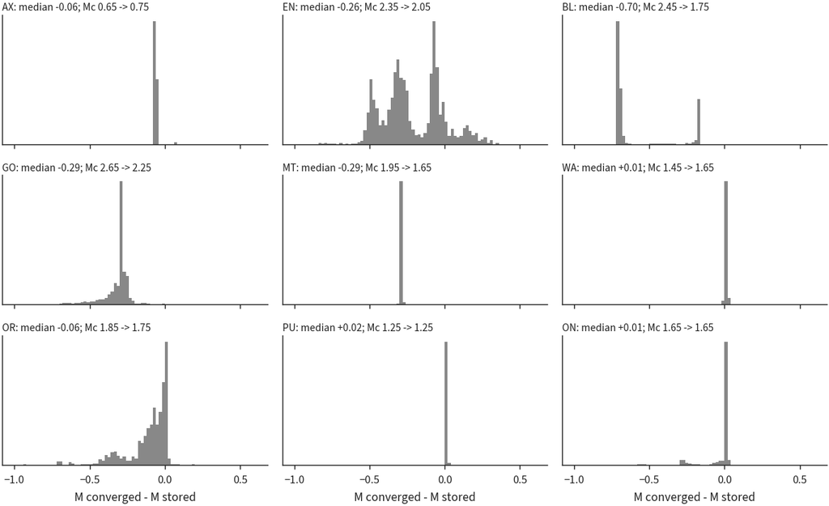

Fig. 1. Converged minus stored magnitude of the v6.0 events with M in both, per region box, and Mc with the stored and with the converged magnitudes on the v6.0 locations.

## Against v4.1 (converged magnitudes)

v4.1 clustering with the converged magnitudes (the paper run, `data/catalog_v4/clusters_zbz/` on main): 1,966 families (913 / 193 / 860), 27,423 events above Mc, 59.4 % background.

| region | Mc_v41 | Mc_v60 | b_v41 | b_v60 | eta0_v41 | eta0_v60 | D_v41 | D_v60 | bg_v41 | bg_v60 | fam_v41 | fam_v60 | sw_v41 | sw_v60 |
| --- | --- | --- | --- | --- | --- | --- | --- | --- | --- | --- | --- | --- | --- | --- |
| AX | 0.85 | 0.75 | 0.77 | 0.71 | -5.56 | -6.11 | 2.32 | 2.46 | 51.60 | 61.30 | 362 | 249 | 37 | 33 |
| EN | 2.25 | 2.05 | 0.84 | 0.86 | -4.50 | -4.40 | 2.86 | 3.38 | 52.70 | 49.30 | 25 | 35 | 4 | 4 |
| BL | 1.75 | 1.75 | 1.17 | 1.18 | -5.74 | -5.77 | 2.93 | 2.95 | 49.80 | 49.40 | 711 | 766 | 91 | 96 |
| GO | 2.25 | 2.25 | 1.16 | 1.18 | -5.36 | -5.59 | 2.78 | 2.85 | 62.50 | 63.30 | 81 | 85 | 11 | 11 |
| MT | 1.85 | 1.65 | 1.03 | 1.05 | -5.18 | -5.26 | 2.56 | 2.37 | 58.60 | 57.00 | 233 | 376 | 8 | 14 |
| WA | 1.65 | 1.65 | 1.14 | 1.13 | -3.40 | -3.57 | 1.72 | 1.85 | 82.50 | 82.50 | 30 | 29 | 2 | 2 |
| OR | 1.85 | 1.75 | 1.22 | 1.11 | -3.71 | -3.01 | 1.74 | 1.73 | 66.70 | 63.20 | 25 | 31 | 1 | 3 |
| PU | 1.35 | 1.25 | 1.32 | 1.27 | -4.29 | -4.26 | 1.79 | 1.86 | 78.70 | 77.70 | 204 | 236 | 12 | 14 |
| ON | 1.65 | 1.65 | 1.04 | 0.94 | -4.17 | -3.89 | 1.86 | 2.25 | 70.00 | 67.00 | 295 | 294 | 27 | 37 |

v4.1 families in v6.0: kept 1444, dissolved 361, grown 74, merged 54, split 28, changed 5. v6.0 families against v4.1: kept 1490, new 478, split_part 45, changed 40, merged 31, grown 17 (column v4_status of the family table).

## Largest families

| family_id | region | region_v51 | type | start | n ≥ Mc | n all | Mmax | duration90_days | extent_km | v51_status | v5.1 family | v5.1 n all | v5.1 type | v4_status |
| --- | --- | --- | --- | --- | --- | --- | --- | --- | --- | --- | --- | --- | --- | --- |
| 1139 | MT | Gorda | mainshock-aftershock | 2014-03-10 | 1298 | 2521 | 6.80 | 88.35 | 140.07 | kept | 1162 | 2358 | mainshock-aftershock | kept |
| 5 | MT | Offshore forearc | mainshock-aftershock | 2010-01-10 | 618 | 1794 | 6.50 | 80.89 | 75.45 | kept | 5 | 1668 | mainshock-aftershock | kept |
| 457 | BL | Blanco | swarm | 2012-10-02 | 665 | 1468 | 4.28 | 3.21 | 16.50 | kept | 427 | 1447 | swarm | kept |
| 1140 | BL | Blanco | mainshock-aftershock | 2014-03-11 | 343 | 1049 | 4.62 | 4.76 | 11.04 | grown | 1170 | 480 | swarm | kept |
| 1920 | BL | Blanco | swarm | 2015-06-01 | 291 | 841 | 5.89 | 47.64 | 53.62 | kept | 1932 | 744 | swarm | kept |
| 1568 | MT | Mendocino | mainshock-aftershock | 2015-01-28 | 90 | 652 | 5.71 | 53.25 | 38.67 | kept | 1536 | 682 | mainshock-aftershock | kept |
| 1844 | AX | Axial | swarm | 2015-04-24 | 442 | 457 | 4.25 | 0.56 | 6.78 | kept | 1872 | 513 | swarm | kept |
| 1458 | BL | Blanco | mainshock-aftershock | 2014-11-23 | 179 | 453 | 5.23 | 11.14 | 14.10 | kept | 1453 | 362 | mainshock-aftershock | kept |
| 144 | ON | Cascades | swarm | 2011-01-28 | 18 | 431 | 3.96 | 28.35 | 16.66 | kept | 150 | 358 | swarm | kept |
| 625 | BL | Blanco | mainshock-aftershock | 2013-01-30 | 64 | 422 | 5.35 | 301.84 | 26.14 | grown | 597 | 128 | mainshock-aftershock | kept |
| 1840 | GO | Mendocino | mainshock-aftershock | 2015-04-24 | 22 | 393 | 5.45 | 10.89 | 30.42 | kept | 1867 | 374 | mainshock-aftershock | kept |
| 837 | ON | Cascades | swarm | 2013-08-03 | 28 | 385 | 3.52 | 195.48 | 0.53 | kept | 830 | 338 | swarm | kept |
| 10 | MT | Mendocino | mainshock-aftershock | 2010-02-04 | 159 | 350 | 5.88 | 32.47 | 58.84 | kept | 10 | 329 | mainshock-aftershock | kept |
| 222 | ON | Offshore forearc | mainshock-aftershock | 2011-09-09 | 167 | 315 | 6.41 | 279.80 | 53.15 | kept | 228 | 229 | mainshock-aftershock | kept |
| 1203 | EN | Explorer | mainshock-aftershock | 2014-04-24 | 148 | 274 | 6.53 | 19.16 | 95.48 | kept | 833 | 300 | mainshock-aftershock | kept |
| 1939 | BL | Blanco | swarm | 2015-06-27 | 114 | 218 | 3.29 | 1.71 | 14.20 | merged | 1948 | 50 | swarm | merged |
| 1013 | PU | Puget/Georgia | mainshock-aftershock | 2013-12-06 | 30 | 203 | 3.45 | 103.28 | 0.41 | kept | 1027 | 205 | mainshock-aftershock | kept |
| 311 | BL | Blanco | swarm | 2012-02-15 | 122 | 179 | 5.95 | 142.37 | 49.08 | kept | 302 | 163 | swarm | kept |
| 1317 | MT | Offshore forearc | mainshock-aftershock | 2014-07-28 | 14 | 169 | 3.23 | 6.07 | 0.29 | kept | 1364 | 161 | mainshock-aftershock | kept |
| 433 | MT | Mendocino | mainshock-aftershock | 2012-09-14 | 14 | 165 | 4.73 | 21.85 | 5.31 | kept | 402 | 141 | mainshock-aftershock | kept |

## Known sequences

| label | expected | region | M | role | family_id | type | n | n_all | Mmax | M2 | duration90_days | extent_km | v51_type | v51_n | v51_n_all |
| --- | --- | --- | --- | --- | --- | --- | --- | --- | --- | --- | --- | --- | --- | --- | --- |
| 2010-01-10 Mw 6.5 Gorda | mainshock-aftershock | MT | 6.50 | mainshock | 5 | mainshock-aftershock | 618 | 1794 | 6.50 | 4.89 | 80.90 | 75.40 | mainshock-aftershock | 579 | 1668 |
| 2014-03-10 Mw 6.8 Gorda | mainshock-aftershock | MT | 6.80 | mainshock | 1139 | mainshock-aftershock | 1298 | 2521 | 6.80 | 4.79 | 88.40 | 140.10 | mainshock-aftershock | 1239 | 2358 |
| 2011-09-09 Mw 6.4 Vancouver Island | mainshock-aftershock | ON | 6.41 | mainshock | 222 | mainshock-aftershock | 167 | 315 | 6.41 | 4.73 | 279.80 | 53.10 | mainshock-aftershock | 133 | 229 |
| 2014-04-24 Mw 6.5 Vancouver Island | mainshock-aftershock | EN | 6.53 | mainshock | 1203 | mainshock-aftershock | 148 | 274 | 6.53 | 5.07 | 19.20 | 95.50 | mainshock-aftershock | 107 | 300 |
| 2012-11-08 Mw 6.1 Explorer plate | mainshock-aftershock | EN | 6.14 | mainshock | 512 | mainshock-aftershock | 23 | 91 | 6.14 | 2.93 | 9.40 | 37.80 | mainshock-aftershock | 21 | 91 |
| 2015-01-28 Mw 5.7 Mendocino fault zone | mainshock-aftershock | MT | 5.71 | mainshock | 1568 | mainshock-aftershock | 90 | 652 | 5.71 | 4.12 | 53.20 | 38.70 | mainshock-aftershock | 90 | 682 |
| 2015-06-01 Mw 5.8, 5.4, 5.9 Blanco triplet | swarm or multiplet | BL | 5.80 | swarm | 1920 | swarm | 291 | 841 | 5.89 | 5.80 | 47.60 | 53.60 | swarm | 101 | 744 |
| 2012-02/04 Mw 5.8 and 6.0 Blanco | swarm or multiplet | BL | 5.95 | swarm | 311 | swarm | 122 | 179 | 5.95 | 5.83 | 142.40 | 49.10 | swarm | 96 | 163 |
| 2016-12-08 Mw 6.6 Mendocino fracture zone (v4.1 addition) | mainshock-aftershock | GO | 6.60 | mainshock | 2097 | mainshock-aftershock | 4 | 4 | 6.60 | 4.71 | 16.90 | 77.50 | mainshock-aftershock | 4 | 4 |
| 2015-04-24 Axial Seamount eruption onset | swarm | AX | 4.25 | largest event | 1844 | swarm | 442 | 457 | 4.25 | 4.13 | 0.60 | 6.80 | swarm | 495 | 513 |

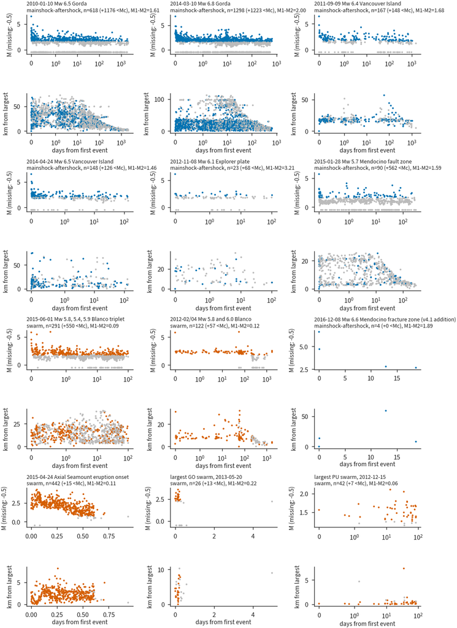

## Rescaled time and distance, thresholds

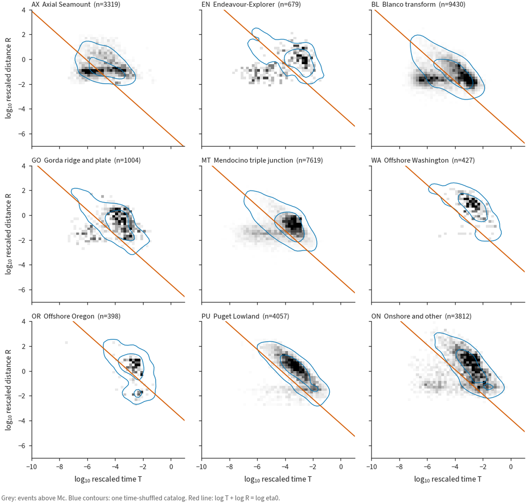

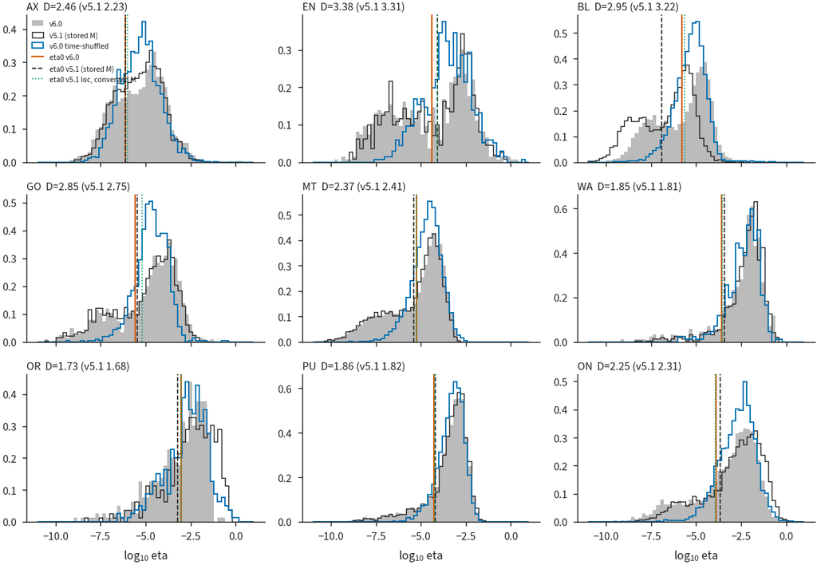

Time-shuffled catalogs (3 seeds, times permuted within each region): share of events below the real eta0 and mixture separation D.

| region | n | frac_below_eta0 | frac_linked | ashman_D |
| --- | --- | --- | --- | --- |
| AX | 3320 | 0.22 | 0.22 | 0.59 |
| EN | 680 | 0.24 | 0.12 | 1.46 |
| BL | 9431 | 0.27 | 0.19 | 0.43 |
| GO | 1005 | 0.14 | 0.09 | 0.67 |
| MT | 7620 | 0.24 | 0.17 | 1.23 |
| WA | 428 | 0.07 | 0.04 | 1.47 |
| OR | 399 | 0.32 | 0.20 | 1.73 |
| PU | 4058 | 0.10 | 0.05 | 1.27 |
| ON | 3813 | 0.11 | 0.08 | 1.06 |

### Null test of the links (real thresholds)

| null | region | n_seeds | frac_linked_mean | real_frac_linked | link_ratio_null_over_real | D_mean | real_ashman_D | n_swarm_mean | real_n_swarm | swarm_ratio_null_over_real | family_ratio_null_over_real |
| --- | --- | --- | --- | --- | --- | --- | --- | --- | --- | --- | --- |
| region | AX | 10 | 0.235 | 0.312 | 0.751 | 0.549 | 2.461 | 13.000 | 33 | 0.394 | 0.910 |
| region | BL | 10 | 0.184 | 0.425 | 0.433 | 0.422 | 2.946 | 15.300 | 96 | 0.159 | 0.589 |
| region | EN | 10 | 0.125 | 0.456 | 0.275 | 1.392 | 3.384 | 1.300 | 4 | 0.325 | 1.014 |
| region | GO | 10 | 0.094 | 0.284 | 0.332 | 0.310 | 2.848 | 0.100 | 11 | 0.009 | 0.318 |
| region | MT | 10 | 0.169 | 0.380 | 0.443 | 1.116 | 2.369 | 9.700 | 14 | 0.693 | 0.604 |
| region | ON | 10 | 0.077 | 0.253 | 0.304 | 1.147 | 2.255 | 5.300 | 37 | 0.143 | 0.470 |
| region | OR | 10 | 0.180 | 0.291 | 0.621 | 2.453 | 1.727 | 2.000 | 3 | 0.667 | 0.552 |
| region | PU | 10 | 0.055 | 0.164 | 0.335 | 1.291 | 1.862 | 1.000 | 14 | 0.071 | 0.517 |
| region | WA | 10 | 0.040 | 0.107 | 0.367 | 1.550 | 1.851 | 0.000 | 2 | 0.000 | 0.352 |
| region_month | AX | 5 | 0.252 | 0.312 | 0.807 | 2.088 | 2.461 | 10.000 | 33 | 0.303 | 0.801 |
| region_month | BL | 5 | 0.267 | 0.425 | 0.628 | 1.457 | 2.946 | 30.800 | 96 | 0.321 | 0.688 |
| region_month | EN | 5 | 0.355 | 0.456 | 0.778 | 2.836 | 3.384 | 5.400 | 4 | 1.350 | 1.160 |
| region_month | GO | 5 | 0.172 | 0.284 | 0.608 | 1.316 | 2.848 | 4.800 | 11 | 0.436 | 0.713 |
| region_month | MT | 5 | 0.302 | 0.380 | 0.793 | 2.026 | 2.369 | 10.600 | 14 | 0.757 | 0.586 |
| region_month | ON | 5 | 0.205 | 0.253 | 0.812 | 1.476 | 2.255 | 25.400 | 37 | 0.686 | 0.783 |
| region_month | OR | 5 | 0.283 | 0.291 | 0.972 | 1.810 | 1.727 | 2.400 | 3 | 0.800 | 0.916 |
| region_month | PU | 5 | 0.136 | 0.164 | 0.828 | 1.566 | 1.862 | 16.600 | 14 | 1.186 | 0.819 |
| region_month | WA | 5 | 0.101 | 0.107 | 0.939 | 1.610 | 1.851 | 1.400 | 2 | 0.700 | 0.986 |
| region_year | AX | 5 | 0.235 | 0.312 | 0.754 | 0.629 | 2.461 | 12.200 | 33 | 0.370 | 0.897 |
| region_year | BL | 5 | 0.197 | 0.425 | 0.463 | 1.204 | 2.946 | 20.800 | 96 | 0.217 | 0.643 |
| region_year | EN | 5 | 0.246 | 0.456 | 0.539 | 1.974 | 3.384 | 3.200 | 4 | 0.800 | 1.160 |
| region_year | GO | 5 | 0.080 | 0.284 | 0.281 | 1.173 | 2.848 | 1.200 | 11 | 0.109 | 0.414 |
| region_year | MT | 5 | 0.243 | 0.380 | 0.638 | 1.614 | 2.369 | 9.800 | 14 | 0.700 | 0.582 |
| region_year | ON | 5 | 0.136 | 0.253 | 0.537 | 1.256 | 2.255 | 12.600 | 37 | 0.341 | 0.628 |
| region_year | OR | 5 | 0.236 | 0.291 | 0.812 | 1.520 | 1.727 | 1.400 | 3 | 0.467 | 0.761 |
| region_year | PU | 5 | 0.085 | 0.164 | 0.514 | 1.399 | 1.862 | 7.200 | 14 | 0.514 | 0.606 |
| region_year | WA | 5 | 0.054 | 0.107 | 0.500 | 1.499 | 1.851 | 1.000 | 2 | 0.500 | 0.476 |

## Sensitivity variants

| variant | n_analysis | pct_background | n_families | n_MA | n_swarm | n_multiplet | n_MA_ge5 | agree_with_main |
| --- | --- | --- | --- | --- | --- | --- | --- | --- |
| main | 30754.0 | 59.6 | 2101.0 | 975.0 | 214.0 | 912.0 | 147.0 |  |
| d3 | 30754.0 | 63.5 | 1973.0 | 895.0 | 193.0 | 885.0 | 123.0 | 0.928 |
| d3q | 30754.0 | 60.6 | 2051.0 | 957.0 | 198.0 | 896.0 | 141.0 | 0.960 |
| mc+0.3 | 14386.0 | 60.2 | 963.0 | 461.0 | 107.0 | 395.0 | 70.0 | 0.937 |
| mc_best | 49392.0 | 61.5 | 3404.0 | 1551.0 | 330.0 | 1523.0 | 234.0 | 0.958 |
| df_est | 30754.0 | 60.1 | 2019.0 | 963.0 | 199.0 | 857.0 | 144.0 | 0.969 |
| df1.3 | 30754.0 | 60.2 | 2020.0 | 957.0 | 198.0 | 865.0 | 146.0 | 0.972 |
| df2.0 | 30754.0 | 59.0 | 2186.0 | 1010.0 | 223.0 | 953.0 | 154.0 | 0.968 |
| noM_floor | 71911.0 | 58.3 | 5369.0 | 1567.0 | 692.0 | 3110.0 | 351.0 | 0.921 |
| mc_year | 53707.0 | 65.0 | 3579.0 | 1672.0 | 321.0 | 1586.0 | 256.0 | 0.957 |
| eta0_shuf5 | 30754.0 | 71.8 | 1716.0 | 842.0 | 132.0 | 742.0 | 110.0 | 0.878 |
| tierABC | 25887.0 | 56.3 | 1907.0 | 888.0 | 195.0 | 824.0 | 127.0 | 0.983 |
| storedM | 30123.0 | 61.2 | 2127.0 | 1000.0 | 208.0 | 919.0 | 131.0 | 0.970 |

agree_with_main: share of the events in both analysis sets that have the same background / clustered label as in the main run. d3 uses every depth (the Axial depth offset of D-B100 enters it); d3q only pairs with two well-constrained depths.

Axial in each variant:

| variant | n_analysis | Mc | log_eta0 | pct_background | n_families | n_swarm |
| --- | --- | --- | --- | --- | --- | --- |
| main | 3320 | 0.75 | -6.11 | 61.30 | 249 | 33 |
| d3 | 3320 | 0.75 | -6.12 | 63.50 | 237 | 24 |
| d3q | 3320 | 0.75 | -6.01 | 59.70 | 256 | 29 |
| mc+0.3 | 1958 | 1.05 | -6.04 | 55.30 | 133 | 22 |
| mc_best | 7750 | 0.30 | -6.36 | 71.00 | 542 | 40 |
| df_est | 3320 | 0.75 | -5.89 | 55.50 | 282 | 33 |
| df1.3 | 3320 | 0.75 | -5.93 | 57.00 | 273 | 33 |
| df2.0 | 3320 | 0.75 | -6.40 | 65.70 | 235 | 27 |
| noM_floor | 16145 | 0.75 | -5.17 | 37.00 | 1905 | 372 |
| mc_year | 6723 |  | -6.57 | 76.70 | 413 | 30 |
| eta0_shuf5 | 3320 | 0.75 | -6.98 | 80.30 | 176 | 11 |
| tierABC | 2113 | 0.75 | -5.70 | 41.00 | 198 | 27 |
| storedM | 4411 | 0.65 | -6.26 | 65.20 | 331 | 37 |

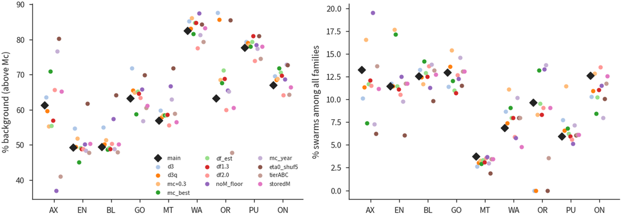

## Families: migration and depth

433 families with 10 or more events; 11 migrating by the permutation test (radial Spearman rho >= 0.5, p_perm < 0.01, positive speed, 90 % radius at least twice the median horizontal error).

| family_id | region | type | start | n | n_all | mig_n | mig_rho | mig_p_perm | mig_v_radial_km_day | mig_r90_km | h_err_med_km | D90_m2s | env_p | mig_style | v51_status |
| --- | --- | --- | --- | --- | --- | --- | --- | --- | --- | --- | --- | --- | --- | --- | --- |
| 150 | PU | mainshock-aftershock | 2011-02-08 | 4 | 20 | 18 | 0.64 | 0.01 | 0.02 | 6.34 | 0.68 | 1.86 |  | too few events for the envelope | changed |
| 194 | PU | swarm | 2011-06-06 | 7 | 10 | 10 | 0.91 | 0.00 | 0.07 | 2.51 | 0.39 | 0.75 |  | too few events for the envelope | kept |
| 304 | EN | mainshock-aftershock | 2012-02-04 | 74 | 137 | 124 | 0.72 | 0.00 | 0.88 | 15.55 | 2.38 | 91.82 | 0.10 | slower than sqrt(t) | kept |
| 448 | BL | mainshock-aftershock | 2012-09-28 | 21 | 62 | 60 | 0.54 | 0.00 | 1.99 | 2.91 | 1.37 | 17.92 | 0.47 | sqrt(t)-like | kept |
| 677 | GO | mainshock-aftershock | 2013-03-30 | 11 | 53 | 48 | 0.62 | 0.00 | 0.00 | 5.29 | 1.85 | 5.42 | 0.16 | slower than sqrt(t) | kept |
| 685 | PU | mainshock-aftershock | 2013-04-07 | 17 | 59 | 51 | 0.52 | 0.00 | 0.00 | 4.33 | 0.17 | 1.27 | 0.36 | sqrt(t)-like | kept |
| 741 | GO | swarm | 2013-05-20 | 26 | 39 | 37 | 0.52 | 0.00 | 9.22 | 5.58 | 1.59 | 144.64 |  | too few events for the envelope | kept |
| 1371 | PU | mainshock-aftershock | 2014-09-17 | 6 | 24 | 23 | 0.58 | 0.01 | 0.09 | 9.17 | 0.84 | 4.12 |  | too few events for the envelope | kept |
| 1552 | MT | mainshock-aftershock | 2015-01-14 | 6 | 33 | 26 | 0.55 | 0.01 | 0.20 | 4.92 | 1.76 | 21.98 | 0.28 | slower than sqrt(t) | kept |
| 1612 | GO | multiplet | 2015-02-12 | 4 | 31 | 26 | 0.58 | 0.01 | 7.72 | 4.86 | 2.00 | 91.97 |  | too few events for the envelope | kept |
| 1939 | BL | swarm | 2015-06-27 | 114 | 218 | 202 | 0.63 | 0.00 | 2.45 | 7.75 | 3.11 | 43.97 | 0.46 | sqrt(t)-like | merged |

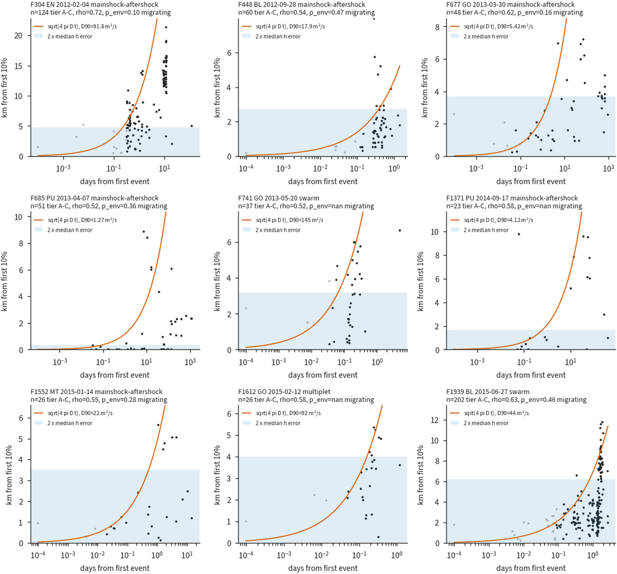

Depth of swarm and mainshock-aftershock families (family medians of depth_good members, Mann-Whitney):

| events | region | n_swarm_families | n_MA_families | swarm_family_median_km | MA_family_median_km | swarm_event_median_km | MA_event_median_km | p_mannwhitney | n_tests | p_bonferroni |
| --- | --- | --- | --- | --- | --- | --- | --- | --- | --- | --- |
| all | AX | 28 | 85 | 3.7 | 3.5 | 3.7 | 3.5 | 0.197 | 8 | 1 |
| all | EN | 0 | 1 |  | 32.1 |  | 31.7 |  | 8 |  |
| all | BL | 32 | 88 | 7.9 | 8.7 | 7.9 | 10.5 | 0.284 | 8 | 1 |
| all | GO | 7 | 19 | 17.5 | 20.4 | 17.7 | 30.7 | 0.497 | 8 | 1 |
| all | MT | 13 | 138 | 18.9 | 25.4 | 18.9 | 23.6 | 0.0301 | 8 | 0.24 |
| all | WA | 2 | 8 | 22.9 | 21.4 | 13.2 | 17.9 | 0.889 | 8 | 1 |
| all | OR | 2 | 4 | 13.7 | 22 | 12.1 | 30.1 | 0.533 | 8 | 1 |
| all | PU | 14 | 75 | 15.2 | 16.3 | 16.3 | 17.5 | 0.991 | 8 | 1 |
| all | ON | 29 | 48 | 9.4 | 13.4 | 8.9 | 15.4 | 0.0173 | 8 | 0.138 |
| without_P1_P3 | AX | 28 | 85 | 3.7 | 3.5 | 3.7 | 3.5 | 0.197 | 8 | 1 |
| without_P1_P3 | EN | 0 | 1 |  | 32.1 |  | 32.1 |  | 8 |  |
| without_P1_P3 | BL | 32 | 88 | 7.9 | 8.7 | 7.9 | 10.5 | 0.284 | 8 | 1 |
| without_P1_P3 | GO | 7 | 19 | 17.5 | 20.4 | 17.7 | 30.6 | 0.497 | 8 | 1 |
| without_P1_P3 | MT | 13 | 136 | 18.9 | 25.4 | 18.9 | 23.5 | 0.0324 | 8 | 0.259 |
| without_P1_P3 | WA | 2 | 8 | 22.9 | 21.4 | 13.2 | 17.9 | 0.711 | 8 | 1 |
| without_P1_P3 | OR | 2 | 4 | 13.7 | 22.2 | 12.1 | 30.2 | 0.533 | 8 | 1 |
| without_P1_P3 | PU | 14 | 75 | 15.2 | 16.3 | 16.3 | 17.5 | 0.991 | 8 | 1 |
| without_P1_P3 | ON | 28 | 47 | 9 | 13.8 | 8.3 | 15.4 | 0.0112 | 8 | 0.0898 |

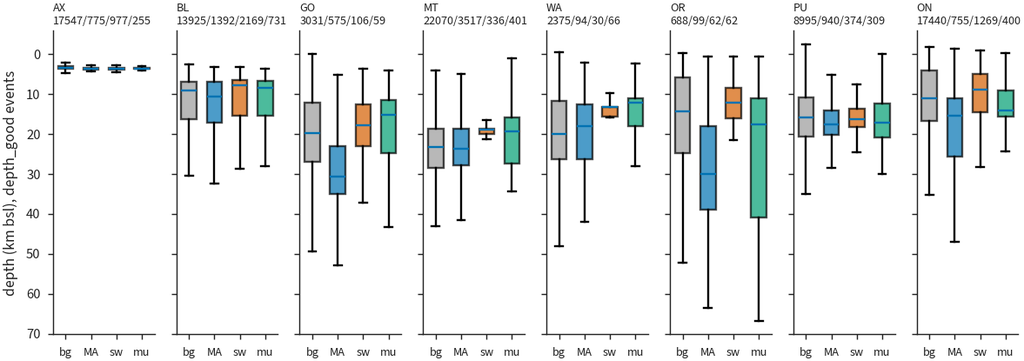

## Fault surfaces v1

142 surfaces hold v6.0 events joined by ID. The join uses the v5.1-location assignment: of the 65,709 events on a surface (on_surface_strict), 7,557 moved more than 2 km horizontally from v5.1 to v6.0 (median 0.73 km), so their v6.0 epicentre may no longer be within the 2 km of the strict rule.

| surface_id | region | kind | n_events_joined | n_analysis | pct_background | pct_swarm | n_families | n_swarm_families | swarm_share_top1 |
| --- | --- | --- | --- | --- | --- | --- | --- | --- | --- |
| v1_BL001 | BL | steep zone (fault candidate) | 5403 | 1463 | 31.60 | 35.50 | 145 | 16 | 0.62 |
| v1_BL002 | BL | steep zone (fault candidate) | 4408 | 1046 | 40.60 | 37.40 | 116 | 21 | 0.42 |
| v1_BL003 | BL | steep zone (fault candidate) | 2396 | 582 | 67.40 | 6.00 | 77 | 7 | 0.63 |
| v1_BL005 | BL | steep zone (fault candidate) | 2260 | 578 | 52.90 | 17.10 | 87 | 19 | 0.31 |
| v1_BL004 | BL | steep zone (fault candidate) | 2431 | 495 | 44.20 | 23.40 | 95 | 24 | 0.14 |
| v1_MT009 | MT | steep zone (fault candidate) | 785 | 457 | 7.20 | 0.00 | 3 | 0 |  |
| v1_MT003 | MT | dipping zone | 2471 | 421 | 71.30 | 0.00 | 49 | 0 |  |
| v1_MT002 | MT | dipping zone | 2736 | 420 | 73.80 | 1.20 | 46 | 1 | 1.00 |
| v1_MT005 | MT | dipping zone | 1531 | 416 | 66.30 | 0.00 | 34 | 0 |  |
| v1_BL009 | BL | steep zone (fault candidate) | 877 | 375 | 47.20 | 21.90 | 92 | 24 | 0.10 |
| v1_GO001 | GO | steep zone (fault candidate) | 979 | 348 | 78.20 | 0.00 | 25 | 0 |  |
| v1_MT008 | MT | steep zone (fault candidate) | 869 | 337 | 64.70 | 0.00 | 41 | 0 |  |
| v1_BL008 | BL | steep zone (fault candidate) | 1114 | 320 | 59.10 | 13.80 | 59 | 9 | 0.61 |
| v1_BL006 | BL | steep zone (fault candidate) | 1701 | 315 | 45.40 | 31.70 | 47 | 15 | 0.31 |
| v1_BL007 | BL | steep zone (fault candidate) | 1343 | 305 | 53.80 | 15.70 | 56 | 8 | 0.62 |
| v1_MT007 | MT | dipping zone | 991 | 303 | 49.20 | 4.60 | 29 | 3 | 0.43 |
| v1_MT001 | MT | steep zone (fault candidate) | 3102 | 289 | 53.30 | 11.80 | 32 | 3 | 0.41 |
| v1_MT013 | MT | steep zone (fault candidate) | 481 | 258 | 11.60 | 0.00 | 2 | 0 |  |
| v1_BL010 | BL | steep zone (fault candidate) | 755 | 212 | 39.60 | 16.50 | 28 | 8 | 0.37 |
| v1_MT004 | MT | dipping zone | 1548 | 185 | 69.70 | 1.10 | 23 | 1 | 1.00 |
| v1_MT017 | MT | steep zone (fault candidate) | 289 | 184 | 14.70 | 0.00 | 3 | 0 |  |
| v1_BL011 | BL | steep zone (fault candidate) | 543 | 184 | 77.70 | 1.60 | 21 | 1 | 1.00 |
| v1_BL013 | BL | steep zone (fault candidate) | 349 | 175 | 76.00 | 1.10 | 22 | 1 | 1.00 |
| v1_PU009 | PU | steep zone (fault candidate) | 172 | 143 | 19.60 | 49.70 | 17 | 4 | 0.58 |
| v1_BL012 | BL | steep zone (fault candidate) | 440 | 135 | 40.70 | 25.20 | 21 | 8 | 0.77 |

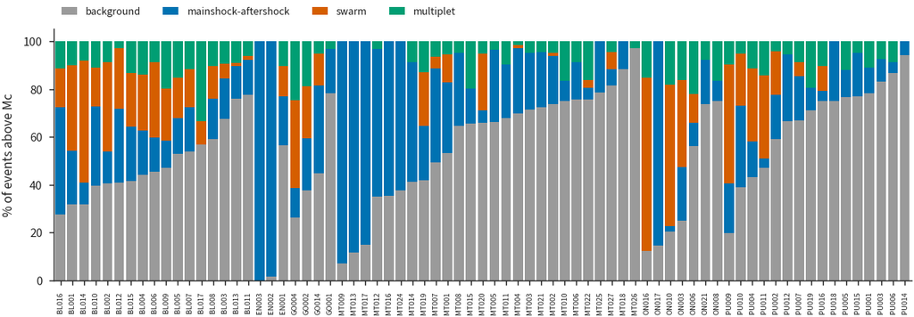

## Swarm scan (DBSCAN, all magnitudes)

470 space-time clusters (311 swarm-like); scan of v5.1: 425 clusters. v5.1 clusters in v6.0: kept 395, dissolved 14, split 7, merged 6, grown 3. v6.0 clusters against v5.1: kept 398, new 54, split_part 15, merged 3. The scan does not use magnitudes, so these changes come from the locations and the not-earthquake flags.

| region | clusters | events | swarm_like |
| --- | --- | --- | --- |
| Axial Seamount | 21 | 1519 | 16 |
| Blanco transform | 231 | 12514 | 165 |
| Endeavour - Explorer | 10 | 544 | 4 |
| Gorda plate | 40 | 1237 | 27 |
| Mendocino triple junction | 58 | 4198 | 30 |
| Offshore Oregon | 1 | 21 | 1 |
| Offshore Washington | 1 | 21 | 0 |
| Other | 96 | 3304 | 62 |
| Puget Lowland | 12 | 372 | 6 |

## Independent check

The verifier script of v5.1 (`v02_zbz_independent.py`, written from the method description without the builder's code) was pointed at v6.0 and extended with a member-set comparison of every family and its own classification (`/wd1/mdenolle_data/catalog_v6/v6.0_analysis/verify_clusters/v02_zbz_independent_v60.py`). Its log:

```
          Mc      b  n_above  Mc_builder  b_builder
region
AX      0.75  0.715     3320        0.75      0.713
EN      2.05  0.867      680        2.05      0.863
BL      1.75  1.181     9431        1.75      1.178
GO      2.25  1.180     1005        2.25      1.179
MT      1.65  1.055     7620        1.65      1.053
WA      1.65  1.129      428        1.65      1.129
OR      1.75  1.106      399        1.75      1.106
PU      1.25  1.273     4058        1.25      1.269
ON      1.65  0.938     3813        1.65      0.937
analysis set 30754
      thr     w1    mu1    sd1    mu2    sd2      D         ll  thr_builder  D_builder
AX -6.113  0.311 -6.880  0.767 -4.664  1.017  2.461  -5743.379       -6.112      2.461
EN -4.396  0.492 -6.453  1.265 -2.750  0.891  3.384  -1396.752       -4.396      3.384
BL -5.770  0.460 -7.199  1.048 -4.693  0.590  2.946 -15919.108       -5.771      2.946
GO -5.592  0.313 -7.101  1.314 -3.976  0.828  2.847  -1847.299       -5.590      2.848
MT -5.257  0.436 -6.730  1.386 -4.237  0.544  2.369 -12811.359       -5.256      2.369
WA -3.574  0.176 -4.568  1.820 -2.033  0.662  1.851   -620.133       -3.572      1.851
OR -3.004  0.509 -4.062  1.456 -2.171  0.528  1.727   -656.854       -3.005      1.727
PU -4.259  0.239 -5.201  1.526 -3.064  0.549  1.863  -5618.300       -4.260      1.862
ON -3.890  0.334 -5.242  1.593 -2.401  0.797  2.255  -6928.364       -3.889      2.254
own_thr families 2100 bg% 59.58
{'AX': 61.3, 'BL': 49.4, 'EN': 49.3, 'GO': 63.3, 'MT': 57.0, 'ON': 67.0, 'OR': 63.2, 'PU': 77.7, 'WA': 82.5}
builder_thr families 2101 bg% 59.57
{'AX': 61.3, 'BL': 49.4, 'EN': 49.3, 'GO': 63.3, 'MT': 57.0, 'ON': 67.0, 'OR': 63.2, 'PU': 77.7, 'WA': 82.5}
builder analysis set 30754 mine 30754 common 30754
only mine 0
region agree 1.0
parent agree 0.9998373719303952 max |dlog_eta| 0.002507342414422631
bg agree (builder thr) 0.9997397950886323
bg agree (own thr) 0.9998698975443161
parent disagreements 5
       reg  par_id  parent_id      leta  log_eta
55665   MT    2021      46257 -3.774446  -3.7739
92013   BL   91995      91177 -4.939792  -4.9407
108425  PU  105899     102137 -2.576363  -2.5770
145302  AX  144515     144831 -5.902869  -5.9012
171510  BL  171353      27442 -3.947699  -3.9500
families: builder 2101, verifier 2101, identical member sets 2096; events in a family on one side only 8
type agreement 0.99762 disagreements 5
type_verifier         mainshock-aftershock  multiplet  no match  swarm
type
mainshock-aftershock                   972          0         3      0
multiplet                                0        911         1      0
swarm                                    0          0         1    213
verifier families by type: {'mainshock-aftershock': 976, 'multiplet': 911, 'swarm': 214}
type agreement on identical member sets 1.0
families whose member sets differ:
  builder F146 (mainshock-aftershock, n=3): verifier family n=4, shared 3; builder-only [], verifier-only [14087]
  builder F457 (swarm, n=665): verifier family n=664, shared 664; builder-only [36483], verifier-only []
  builder F1117 (multiplet, n=2): its members [82797, 82813] are in no verifier family (parents: [27442, 82797])
  builder F1139 (mainshock-aftershock, n=1298): verifier family n=1299, shared 1298; builder-only [], verifier-only [90864]
  builder F1458 (mainshock-aftershock, n=179): verifier family n=178, shared 178; builder-only [125097], verifier-only []
```

### Ten families checked by hand

Member lists in time and space (`/wd1/mdenolle_data/catalog_v6/v6.0_analysis/verify_clusters/v03_spotcheck_v60.py`): every link checked against eta0 and the distance cap, every member's region and time, the distance from the largest event; maps and distance-time plots looked at one by one.

| family_id | region | type | n | n_all | n_members_table | n_in_analysis_table | Mmax | start | end | days | main_first_or_later | dist_from_largest_med_km | dist_from_largest_max_km | n_links | links_below_eta0 | links_within_cap | links_log_eta_reproduced | max_link_km | max_link_days | n_size_ok | hand_check |
| --- | --- | --- | --- | --- | --- | --- | --- | --- | --- | --- | --- | --- | --- | --- | --- | --- | --- | --- | --- | --- | --- |
| 1139 | MT | mainshock-aftershock | 1298 | 2521 | 2521 | 1298 | 6.80 | 2014-03-10T05:04:11 | 2015-12-24T02:35:15 | 653.90 | 1 | 22.06 | 111.97 | 2520 | 2520 | 2520 | 2520 | 111.97 | 653.89 | True | 2014-03-10 Mw 6.8 Gorda (MT). Aftershocks within 0-30 km in the first days, decaying over 650 days; a second group 80-110 km east (from day 10) is joined through the M 6.8 parent, whose cap is 3 L(6.8… |
| 5 | MT | mainshock-aftershock | 618 | 1794 | 1794 | 618 | 6.50 | 2010-01-10T00:27:41 | 2015-10-23T10:04:06 | 2112.40 | 0 | 23.67 | 72.39 | 1793 | 1793 | 1793 | 1793 | 72.39 | 2112.40 | True | 2010-01-10 Mw 6.5 Gorda (MT). Aftershocks up to 70 km in the first days, then a tail that shrinks to the mainshock area and lasts 5.8 years (largest event first). Consistent with the rules (the M 6.5 … |
| 457 | BL | swarm | 665 | 1468 | 1468 | 665 | 4.28 | 2012-10-02T11:47:02 | 2013-03-29T17:06:31 | 178.22 | 300 | 2.04 | 14.44 | 1467 | 1467 | 1467 | 1467 | 9.70 | 177.37 | True | Blanco swarm, Oct 2012 - Mar 2013 (OBS deployment). 665 events above Mc, median 2 km from the largest event, 300 events before it, 178 days. Compact in space; swarm label is right. |
| 565 | PU | swarm | 42 | 49 | 49 | 42 | 2.11 | 2012-12-15T05:44:43 | 2013-03-10T09:36:10 | 85.16 | 11 | 0.22 | 7.36 | 48 | 48 | 48 | 48 | 7.35 | 23.28 | True | Puget Lowland swarm Dec 2012 - Mar 2013: 42 events within 1 km over 85 days, two members at 4.7 and 7.4 km. Swarm label right. |
| 837 | ON | swarm | 28 | 385 | 385 | 28 | 3.52 | 2013-08-03T02:11:16 | 2014-05-18T10:59:59 | 288.37 | 12 | 0.15 | 9.77 | 384 | 384 | 384 | 384 | 9.90 | 267.56 | True | Onshore swarm NW of Mount St Helens, Aug 2013 - May 2014: 28 events above Mc, 357 attached below Mc, nearly all within 0.5 km, burst at day 20. Swarm label right. |
| 396 | MT | multiplet | 2 | 2 | 2 | 2 | 1.81 | 2012-07-16T10:24:15 | 2012-07-16T11:21:08 | 0.04 | 1 | 0.17 | 0.35 | 1 | 1 | 1 | 1 | 0.50 | 0.04 | True | Mendocino doublet, 1 hour apart, 0.35 km. Right. |
| 736 | MT | mainshock-aftershock | 6 | 43 | 43 | 6 | 4.10 | 2013-05-18T14:02:31 | 2013-07-14T14:31:27 | 57.02 | 1 | 2.91 | 9.61 | 42 | 42 | 42 | 42 | 9.61 | 56.94 | True | Mendocino M 4.1 with 5 aftershocks above Mc (37 below), within 10 km, 57 days. Right. |
| 682 | BL | swarm | 12 | 44 | 44 | 12 | 2.67 | 2013-04-05T18:54:43 | 2013-04-07T03:02:43 | 1.34 | 0 | 0.48 | 7.43 | 43 | 43 | 43 | 43 | 7.43 | 1.34 | True | Blanco swarm, 1.3 days, 12 events above Mc within 2 km (two attached events at 7 km). Right. |
| 1480 | AX | mainshock-aftershock | 5 | 5 | 5 | 5 | 2.41 | 2014-12-03T11:59:27 | 2014-12-03T12:06:24 | 0.00 | 1 | 0.67 | 2.36 | 4 | 4 | 4 | 4 | 2.36 | 0.00 | True | Axial: 5 events in 7 minutes within 2.4 km, M 2.41 first and largest; mainshock-aftershock label right. |
| 1844 | AX | swarm | 442 | 457 | 457 | 442 | 4.25 | 2015-04-24T05:13:16 | 2015-04-25T03:44:32 | 0.94 | 37 | 2.03 | 8.18 | 456 | 456 | 456 | 456 | 7.01 | 0.88 | True | Axial 2015 eruption onset: 442 events above Mc in 0.94 days from 2015-04-24 05:13 UTC, within 8 km of the caldera. Swarm label right; the later weeks of the eruption are in other families. |

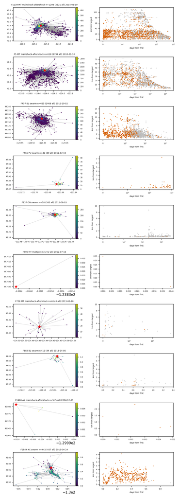

## Files

- `/wd1/mdenolle_data/catalog_v6/v6.0_analysis/clusters/events_zbz_v60.csv.gz`: every catalog row (172,342): class, family, role, parent, eta, position; same columns as events_zbz_v51.csv.gz (region_v51 = catalog region label, identical in v5.1 and v6.0)
- `/wd1/mdenolle_data/catalog_v6/v6.0_analysis/clusters/families_zbz_v60.csv`: every family: v5.1 columns plus v51_status / v51Mc_status (matching with the v5.1 run and the v5.1-locations converged-M run); v4_status is against v4.1 with converged M
- `regions_zbz.csv, thresholds_zbz.csv, completeness_b_df.csv, sensitivity_zbz.csv`: per-region tables
- `v51_families_status.csv, v60_families_status.csv (+ _vs_v51Mc, _vs_v4)`: family matching
- `ref_v51_Mconv/`: the v5.1-locations run with the converged magnitudes
- `variants/`: the twelve sensitivity variants, including storedM
- `/wd1/mdenolle_data/catalog_v6/v6.0_analysis/verify_clusters/`: independent check and spot checks

## References

- Aki, K. (1965). Maximum likelihood estimate of b in the formula log N = a - bM and its confidence limits. Bull. Earthq. Res. Inst. 43, 237-239.
- Baiesi, M., & Paczuski, M. (2004). Scale-free networks of earthquakes and aftershocks. Phys. Rev. E 69, 066106. [doi:10.1103/PhysRevE.69.066106](https://doi.org/10.1103/PhysRevE.69.066106)
- Boettcher, M. S., & McGuire, J. J. (2009). Scaling relations for seismic cycles on mid-ocean ridge transform faults. GRL 36, L21301. [doi:10.1029/2009GL040115](https://doi.org/10.1029/2009GL040115)
- Hsu, Y.-F., Martínez-Garzón, P., Trugman, D. T., & Ben-Zion, Y. (2026). Earthquake clustering and stress inversion in the Mendocino Triple Junction region. GJI 245(3), ggag089. (first author's initials not checked) [doi:10.1093/gji/ggag089](https://doi.org/10.1093/gji/ggag089)
- Kuna, V. M., Nábělek, J. L., & Braunmiller, J. (2019). Mode of slip and crust-mantle interaction at oceanic transform faults. Nat. Geosci. 12, 138-142. [doi:10.1038/s41561-018-0287-1](https://doi.org/10.1038/s41561-018-0287-1)
- McGuire, J. J., Boettcher, M. S., & Jordan, T. H. (2005). Foreshock sequences and short-term earthquake predictability on East Pacific Rise transform faults. Nature 434, 457-461. [doi:10.1038/nature03377](https://doi.org/10.1038/nature03377)
- Roland, E., & McGuire, J. J. (2009). Earthquake swarms on transform faults. GJI 178(3), 1677-1690. [doi:10.1111/j.1365-246X.2009.04214.x](https://doi.org/10.1111/j.1365-246X.2009.04214.x)
- Shapiro, S. A., Huenges, E., & Borm, G. (1997). Estimating the crust permeability from fluid-injection-induced seismic emission at the KTB site. GJI 131(2), F15-F18. [doi:10.1111/j.1365-246X.1997.tb01215.x](https://doi.org/10.1111/j.1365-246X.1997.tb01215.x)
- Vidale, J. E., & Shearer, P. M. (2006). A survey of 71 earthquake bursts across southern California. JGR 111, B05312. [doi:10.1029/2005JB004034](https://doi.org/10.1029/2005JB004034)
- Wells, D. L., & Coppersmith, K. J. (1994). New empirical relationships among magnitude, rupture length, rupture width, rupture area, and surface displacement. BSSA 84, 974-1002.
- Wilcock, W. S. D., et al. (2016). Seismic constraints on caldera dynamics from the 2015 Axial Seamount eruption. Science 354, 1395-1399. [doi:10.1126/science.aah5563](https://doi.org/10.1126/science.aah5563)
- Woessner, J., & Wiemer, S. (2005). Assessing the quality of earthquake catalogues: estimating the magnitude of completeness and its uncertainty. BSSA 95, 684-698.
- Zaliapin, I., Gabrielov, A., Keilis-Borok, V., & Wong, H. (2008). Clustering analysis of seismicity and aftershock identification. PRL 101, 018501. [doi:10.1103/PhysRevLett.101.018501](https://doi.org/10.1103/PhysRevLett.101.018501)
- Zaliapin, I., & Ben-Zion, Y. (2013a). Earthquake clusters in southern California I: Identification and stability. JGR 118, 2847-2864. [doi:10.1002/jgrb.50179](https://doi.org/10.1002/jgrb.50179)
- Zaliapin, I., & Ben-Zion, Y. (2013b). Earthquake clusters in southern California II: Classification and relation to physical properties of the crust. JGR 118, 2865-2877. [doi:10.1002/jgrb.50178](https://doi.org/10.1002/jgrb.50178)
- Zaliapin, I., & Ben-Zion, Y. (2016). A global classification and characterization of earthquake clusters. GJI 207(1), 608-634. [doi:10.1093/gji/ggw300](https://doi.org/10.1093/gji/ggw300)